# Priorities for synthesis research in ecology and environmental science - Halpern - 2023 - Ecosphere - Wiley Online Library

[Ecosphere](https://esajournals.onlinelibrary.wiley.com/journal/21508925)

[Volume 14, Issue 1](https://esajournals.onlinelibrary.wiley.com/toc/21508925/2023/14/1) e4342

[figure not shown]

INNOVATIVE VIEWPOINT

Open Access

# Priorities for synthesis research in ecology and environmental science

[Benjamin S. Halpern](https://esajournals.onlinelibrary.wiley.com/authored-by/Halpern/Benjamin+S.),

[Carl Boettiger](https://esajournals.onlinelibrary.wiley.com/authored-by/Boettiger/Carl),

[Michael C. Dietze](https://esajournals.onlinelibrary.wiley.com/authored-by/Dietze/Michael+C.),

[Jessica A. Gephart](https://esajournals.onlinelibrary.wiley.com/authored-by/Gephart/Jessica+A.),

[Patrick Gonzalez](https://esajournals.onlinelibrary.wiley.com/authored-by/Gonzalez/Patrick),

[Nancy B. Grimm](https://esajournals.onlinelibrary.wiley.com/authored-by/Grimm/Nancy+B.),

[Peter M. Groffman](https://esajournals.onlinelibrary.wiley.com/authored-by/Groffman/Peter+M.),

[Jessica Gurevitch](https://esajournals.onlinelibrary.wiley.com/authored-by/Gurevitch/Jessica),

… See all authors

First published: 11 January 2023

https://doi.org/10.1002/ecs2.4342

Citations: 3

**Handling Editor:** Debra P. C. Peters

**Funding information** National Center for Ecological Analysis and Synthesis (NCEAS); National Science Foundation, Grant/Award Number: 1940692

## Abstract

Synthesis research in ecology and environmental science improves understanding, advances theory, identifies research priorities, and supports management strategies by linking data, ideas, and tools. Accelerating environmental challenges increases the need to focus synthesis science on the most pressing questions. To leverage input from the broader research community, we convened a virtual workshop with participants from many countries and disciplines to examine how and where synthesis can address key questions and themes in ecology and environmental science in the coming decade. Seven priority research topics emerged: (1) diversity, equity, inclusion, and justice (DEIJ), (2) human and natural systems, (3) actionable and use-inspired science, (4) scale, (5) generality, (6) complexity and resilience, and (7) predictability. Additionally, two issues regarding the general practice of synthesis emerged: the need for increased participant diversity and inclusive research practices; and increased and improved data flow, access, and skill-building. These topics and practices provide a strategic vision for future synthesis in ecology and environmental science.

## INTRODUCTION

Planet Earth faces dramatic and accelerating consequences of climate change (IPCC, 2022), biodiversity loss (IPBES, 2019), and expanding and intensifying influences of human activities (Halpern et al., 2019; Venter et al., 2016). It is urgent to understand and forecast the social–ecological effects of these changes so society can build strategies to mitigate, adapt to, or transform these circumstances (Folke et al., 2021), a need that requires transdisciplinary research spanning scales from local to global, integration of multiple knowledge and value systems, and data and analytical tools to support the research. These needs sit squarely within the fields of ecology and environmental science.

The scope, scale, and speed of data collection and availability are increasing rapidly, driven in part by advances in automated field-based sensors (e.g., camera traps, hydraulic flow sensors), satellite-based remote sensing, and coordinated sampling (Farley et al., 2018) along with sustained efforts to gather socioeconomic data. These trends are facilitated by coordinated networks (e.g., National Ecological Observatory Network, Long-Term Ecological Research, Global Ocean Observing System) and distributed research initiatives (e.g., DroughtNet, NutNet) that are creating vast, open data repositories. Although advances in open science have created opportunities for accelerated scientific discovery (Hampton et al., 2017), obstacles remain, such as inadequate rewards for collecting and sharing data, integrating Indigenous knowledge and approaches into data practices, and equitable access to and control of these data (Carroll et al., 2020; Reichman et al., 2011).

Synthesis in ecology and environmental science—bringing together data, ideas, tools, and knowledge (Baron et al., 2017)—is a key approach for understanding complexity across scales, leveraging data from various disciplines, facilitating discovery of general patterns in natural systems, and informing policy (Halpern et al., 2020). Given these potential roles of synthesis science and the pressing need to address environmental challenges, we wanted to reflect on where the greatest opportunities lie for synthesis in ecology and environmental science in the coming decade.

Here we assess the research questions and themes that we, as members of the research community, prioritize as future synthesis needs in ecology and environmental science. To develop these priorities, we convened a virtual workshop at the National Center for Ecological Analysis and Synthesis (NCEAS) on February 17–18, 2021, with 127 participants across career stages, institutions, backgrounds, and geographies, which were selected through an application process (Appendix S1). Participants were drawn from ecology and environmental sciences and largely identified as natural scientists. We asked workshop participants to anonymously identify key synthesis questions in ecology and environmental science, and the challenges and innovations needed to answer those questions. Participants proposed ideas or questions in pre-workshop brainstorming sessions; added and upvoted questions online; and worked in breakout teams during the workshop to refine upvoted questions into lists of top three questions. These final lists were then grouped into themes by the 12-person steering committee and discussed at length by the workshop participants. An overview of the process is shown in Figure 1. We highlight seven emergent research priorities identified by this group and describe core ideas, challenges we face addressing them, and how synthesis can help overcome those challenges. We additionally address two priorities around the practice of synthesis that were extensively discussed during the workshop.

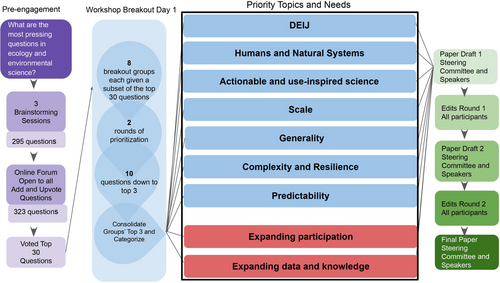

**FIGURE 1**

Our approach to engaging participants and all perspectives in developing, honing, and presenting the set of questions and ideas that form the basis for our recommended priorities. DEIJ is diversity, equity, inclusion, and justice.

## PRIORITY TOPICS

### Diversity, equity, inclusion, and justice

A central priority that emerged was for ecological synthesis on questions that address issues of diversity, equity, inclusion, and justice (DEIJ). Recent work in environmental justice has highlighted important intersections between ecosystem well-being and equity for human societies (Bullard, 2019). Environmental degradation can negatively affect human health, livelihoods, and well-being, with a disproportionate effect on disadvantaged populations, exacerbating societal inequalities (Hoffman et al., 2020). Costs of conservation measures and environmental policies are rarely borne equally. Structural inequalities such as racism and the practices of redlining in cities can also influence ecological and evolutionary processes by leading to an unequal distribution of “nature” and therefore ecological processes within cities (Schell, Dyson, et al., 2020). Explicit integration of DEIJ into synthesis research could improve knowledge by addressing topics of relevance and importance to historically underrepresented groups, and support efforts that simultaneously promote human well-being and conservation.

Lack of diversity among ecologists and environmental scientists, along with scientific and societal institutions that tend to exclude individuals from certain identity groups (Graves et al., 2022), creates inherent barriers to including ideas and perspectives of diverse groups in developing and conducting research. Ecologists and environmental scientists can reduce these barriers by engaging with diverse communities and experts from social science disciplines (Bennett et al., 2017). By increasing diversity of participants, we can better define and answer research questions that inform policy relevant to and impactful on a broader community. In the last section we explore how the process of synthesis science can be made more diverse and inclusive, and beneficial to society as a whole.

### Coupled human–natural systems

Environmental synthesis has provided valuable insights into the causes and impacts of environmental change, but still needs to address the complexities of coupled human–natural systems to understand how human values, decisions, and governance structures affect environmental outcomes (Folke et al., 2021). For example, human population growth, energy use, economic activity, and greenhouse gas policies define emission scenarios of the Intergovernmental Panel on Climate Change (IPCC, 2022), which in turn determine global projections of species extinctions, native and non-native species distributions, and nature's contributions to people under climate change (Chaplin-Kramer et al., 2019). People adapt to environmental changes in ways that mitigate or amplify their effects on ecosystems and societies (Cinner et al., 2018).

Integrating perspectives, approaches, data, and knowledge from diverse fields poses many challenges. Socioeconomic factors act at different spatial or temporal scales from natural systems (Bergsten et al., 2014). For example, ecological regime shifts often proceed quickly and are detected too late to inform management intervention (Biggs et al., 2009). Such scale mismatches between ecological and human systems can cause decreases in resilience in socioecological systems, mismanagement of natural resources, and declines in human well-being (Cumming et al., 2006). Additionally, varied data processing and analysis practices among disciplines challenge effective integration of datasets for systemic understanding. Interdisciplinary data management often requires special consideration for cultural and traditional knowledge and socioeconomic data, underscoring the need for privacy policies and recognition that standardization is not always possible (or desirable) across disciplines.

Synthesis science is well positioned to integrate a broader range of disciplines to understand coupled human–natural systems (Folke et al., 2021). To achieve this integration, scientists and funders can account for the additional time and effort needed to create a shared understanding and language for integrating across disciplinary traditions and approaches.

### Actionable and use-inspired science

Synthesis science in ecology and environmental science is particularly well suited to informing decision makers. Rigorous systematic reviews, meta-analyses, and predictive models can distill research to effectively support environmental policy and management (Pullin et al., 2020). This strength of synthesis science in making inference across diverse systems is also its primary challenge for guiding actions fully connected to local contexts. Like other approaches to conducting use-inspired research, synthesis science has inadequately engaged practitioners to help codevelop questions, research methodologies, and data to be used. For knowledge exchange to be effective and actionable, knowledge can flow bidirectionally or be cocreated through authentic relationships and partnerships in spaces among science, policy, and practice (Jarvis et al., 2020).

Improved communication, coproduction, transparency, and data reuse practices can support evidence-informed decisions (Donnelly et al., 2018). Synthesis scientists can ensure relevance of their work by codeveloping questions with decision makers who address relevant questions on relevant timelines with a clearly defined audience and entry point into management systems (Haddaway et al., 2017). Synthesis science can better embrace local, Indigenous, and experiential knowledge and tools and theories from across social and biophysical sciences and environmental humanities (Bennett et al., 2017). Education around synthesis can focus on honing skills and understanding levers of influence in the nonresearch world, speaking the language of partner organizations or developing shared vocabulary, and investing resources in building and managing connections (Pelletier, 2020).

### Scale

Advancing ecological understanding across spatial and temporal scales remains a challenge to social–ecological research (Kramer et al., 2017; Levin, 1992). Synthesis plays a key role in addressing this challenge by empowering researchers to integrate data and approaches across scales, to assess how insights translate to different scales, and to link these insights to policy and decision-making from local to global scales.

Challenges in addressing questions of scale (spatial, temporal, taxonomic, and governance) arise primarily from (1) scarcity of long-term data, (2) difficulties integrating heterogeneous information in preparation for analyses, (3) limited opportunities and support for developing the skills needed to work across various scales, and (4) barriers to integrating diverse knowledge and perspectives of project partners at different scales. While long-term ecological research has expanded over the last half century, additional commitments to collection, curation, and integration of diverse data over long temporal and large spatial scales are critical for overcoming these obstacles.

### Generality

Science tends to seek general principles that explain patterns and processes. When common principles are not found, it is possible that they exist but there is too much contingency to detect them, or that human impacts obscure them. Synthesis science is well positioned to find generality where it exists and to identify when and why context matters (Lawton, 1999).

Two key challenges, however, persist. First, lack of sufficient replication among comparable studies at different temporal and spatial scales constrains opportunities for synthesis. Emphasis on novelty is at odds with replication of studies. Second, bias in what researchers choose to study and report can limit the material for synthesis and introduce bias.

Several interventions may help distill individual conclusions into generality: incentivizing open science, standardizing reporting, and addressing systematic biases in funding and publication processes. Open science practices that support replication and synthesis (e.g., open science research workflows, freely available datasets and code) are critical for progress but lack support (NASEM, 2021). In addition, shifting emphasis from novelty and speed in funding and publishing toward, for example, distributed experimental networks would facilitate collection of data well suited to testing generalities. Developing incentives and platforms for publishing null or nonsignificant results would ensure that findings from all studies are discoverable, regardless of their outcome. Cross-sectoral and cross-disciplinary working groups that facilitate comparison across ecosystems and integrate empirical with theoretical approaches are one possible way to encourage the broad thinking that would enable progress.

### Complexity and resilience

Ecosystems are inherently complex, particularly when incorporating social, cultural, economic, and political factors. This complexity can create resilience in systems through redundancies in functions and connections (Cowles et al., 2021), but can also cause fragility, as shifts in one system (e.g., economic collapse) can drive major changes in others (e.g., ecosystem tipping points; Folke et al., 2021). This complexity framing is increasingly being used to address issues like water, food, and energy, among others.

Complexity complicates synthesis efforts, in part because it is context dependent, challenging efforts to find generalities, including identifying predictors of ecosystem resilience (Pace et al., 2015). The highly interdisciplinary nature of this research demands equally heterogeneous data, and these data are often not available or not well harmonized. Few scientists are being taught to do interdisciplinary research, limiting the pool of researchers.

Ideally, synthesis research helps build understanding of how complexity structures ecosystem responses and identifies strategies that can bolster provisioning of ecosystem services for the greatest diversity of human needs and the environment. Efforts to push synthesis to be fully interdisciplinary can accelerate progress but will require institutional support and efforts to connect data repositories across disparate disciplines.

### Predictability

This time of unprecedented environmental change increases the need to predict ecosystem condition and the resulting contributions to people at multiple temporal scales (Dietze et al., 2018). Such information is critical for timely adaptive management and conservation (Priority 3). While near-term prediction (months to years) is common in fields such as climate science and finance, it is rare in ecology.

Two perceived challenges to research on near-term predictability center on concerns that current models may not be “good enough” and that inaccurate forecasts could be harmful (e.g., misinform management and conservation decisions). However, predictions do not need to be perfect to advance science and improve decisions if their limits are recognized (Gabrys et al., 2016). The fastest way to improve predictions is to iteratively test and update them, providing continuous feedback and learning (Dietze et al., 2018).

Six strategies can support and accelerate progress of prediction in ecology. First, science will benefit from a culture where prediction is fostered and encouraged, and where failed predictions are expected and used as a platform for learning. Second, standardized observational and experimental studies and data and streamlined integration of heterogeneous data will help support development of ecological forecasting. Third, greater focus on real-time or continuously updated data will help constrain near-real-time forecasts. Fourth, open access tools for automated, reproducible workflows will facilitate analyses, reduce redundancy, and lower barriers to entry for new forecasters and maintenance costs of keeping forecasts online (Fer et al., 2021). Fifth, a revised core curriculum that presents ideas and concepts from a predictive perspective would raise the bar in quantitative learning and provides opportunities to learn forecasting specifically. Finally, clear communication between users and forecasters will help determine which variables are most useful for decision-making and on-the-ground management (Schell, Guy, et al., 2020). Stronger connections between decision science and prediction can help support sustainable natural resource management.

## PROCESS AND PRACTICE OF SYNTHESIS SCIENCE

Two common threads cut across all topics discussed during our workshop: expanding participation and expanding available data.

### Expanding participation in synthesis science

Synthesis science is most powerful when it integrates datasets, perspectives, and insights across regions and ecosystems. By increasing diversity of participants and fostering inclusive research environments, we can better identify and answer research questions that inform just and equitable solutions to pressing challenges. Without prioritizing diversity and inclusion, syntheses risk being biased and less broadly applicable (Hofstra et al., 2020), which may lead to unjust and inequitable outcomes. Although the principles of diversity and inclusion are relevant to any scientific endeavor, they are particularly salient for synthesis given its integrative nature.

The regional to global scale of much of synthesis science emphasizes the value of including people, ideas, and data from multiple cultures, geographies, and languages. Scientific and academic institutions and cultures have historically excluded people on the basis of race, ethnicity, gender, abilities, sexual orientation, and other identities (Bernard & Cooperdock, 2018), as well as from research conducted in their native land (Heberling et al., 2021). Exclusion of local and Indigenous knowledge can be especially detrimental to our understanding of ecological dynamics (Maas et al., 2021; Okeke et al., 2017), particularly of understudied organisms and systems (Mori et al., 2021), and sustainable management of resources amidst ongoing land use and climate change (Robards et al., 2018). Greater effort can be made to prioritize and facilitate representation and integration of diverse scientists and perspectives by providing appropriate funding and compensation, mentoring and education, appropriate authorship credit, and modes for virtual and asynchronous participation (Lashley et al., 2020). Investing in open science and data science skill-building can increase participation in synthesis science.

The use of English in much of the scientific literature, data, and scientific meetings (Amano et al., 2016) creates an additional barrier to participation in synthesis research and often excludes information published in other languages (Amano et al., 2021). Multilingual scientific collaborations and searches can be conducted when doing meta-analysis and synthesis projects (e.g., Nuñez & Amano, 2021).

Although we can strive to assemble diverse groups of people in synthesis science endeavors, the practice of increasing diversity can be ineffective or even harmful to individuals from historically marginalized groups in the absence of concrete steps to ensure inclusion and belonging. Racist, sexist, ableist, and colonial structures have informed many traditional scientific practices and cultural norms. Reimagining systems and institutions to be safe and supportive spaces where everyone can thrive and determine their own questions, approaches, and potential solutions is important (Trisos et al., 2021). Equally important is providing adequate opportunities and support infrastructures for marginalized and underrepresented voices to learn and lead synthesis science (Nocco et al., 2021), and celebrating excellence of specific groups (Miriti et al., 2020; Schell, Guy, et al., 2020).

To advance engagement with marginalized communities, it is important for individuals from dominant groups to engage and participate with humility, curiosity, and patience (Borrelle et al., 2021). Safety and trust among individuals can be fostered by listening, acknowledging shortcomings, and building relationships before acting. Developing a practice of open dialogue and conflict resolution can also help groups engage in inclusive synthesis research and address institutional barriers. Group leaders could also consider allowing for diverse modes of engagement to facilitate greater participation. Fundamentally, building relationships and networks needed to support underrepresented communities and redistributing power among different groups of people in a collaboration can shift power dynamics and can facilitate greater inclusivity in synthesis.

### Expanding the data and knowledge foundation

The quantity of data for use in synthesis science is growing (Farley et al., 2018). Efforts are being made to standardize and synthesize data across multiple existing databases (e.g., Jeliazkov et al., 2020) and harmonize data across scientific networks (e.g., O'Brien et al., 2021). These efforts enable research on ecological questions that could not be addressed by any one database (Bates et al., 2021). However, dedicated funding to support data curation, management, and archiving is needed to advance existing and future efforts.

Careful consideration of the ethics of assembling diverse datasets must be part of any equitable data synthesis future. Some individuals, communities, and institutions may not share their data publicly for privacy, ethical, or safety concerns, or are unable due to legal or policy constraints. Some researchers may be disadvantaged by current open science norms if, by making their data freely available, they effectively cede control of their intellectual property to others with greater resources who can more rapidly use it. This “information drain” from under-resourced institutions, researchers, and countries risks exacerbating existing inequalities in academic output and rewards. Even if there are barriers to providing equal participation opportunities, it is crucial to follow just, equitable, and inclusive practices in authorship and acknowledgment of the diverse people who generate scientific data and improve standards going forward (Armenteras, 2021).

Many potential synthesis datasets are inaccessible or of limited value due to poor-quality metadata (Quarati & Raffaghelli, 2020). Data may be difficult to find or access because they are published in a language that is not native to the investigator, not digitized, or housed in databases with barriers to access (Haddaway & Bayliss, 2015). Alternative forms of data, including qualitative datasets (e.g., traditional knowledge, photographs), tend not to be included in public databases (Moon et al., 2016; Young et al., 2018). Limitations in using these forms of information can hinder our ability to identify ecological patterns and processes (Konno et al., 2020). Tools that aid scientists in accessing diverse data sources, such as machine learning techniques that help identify relevant data sources across many languages (Han et al., 2020), are key to addressing these hurdles. Ultimately, increased inclusion in synthesis efforts through global collaboration across diverse groups of people is one of the best ways to move forward.

## CONCLUSION

The above priorities are neither exhaustive nor represent consensus, but rather emerged from the workshop process as priority topics and themes that synthesized the many individual questions offered by workshop participants (the full list of questions is available at https://doi.org/10.5063/F19885GC). Many were interconnected, with several focusing on interactions between people and nature and others focused on the quest for a science of ecology that can be predictive across scales.

Across all themes, discussions focused on the need for equity through open science as an integral part of how to improve synthesis (Ramachandran et al., 2021). Central to synthesis helping advance science is the need for greater data access and diversity, and education for people to learn how to leverage these data. Greater diversity within teams of scientists and practitioners would provide perspectives and contributions that would better frame synthesis-based questions. Such diversity, along with open science practices and technology that foster sharing of data and ideas, offers great potential for the future of synthesis in ecology and environmental science. Achieving greater inclusion goes far beyond inviting more diverse participants to discussions; it requires fundamental changes in the structure of science education and funding to achieve broad participation and leadership, and acknowledgment of those who generate data. Greater inclusion also requires mechanisms ensuring datasets follow the findability, accessibility, interoperability, reusability (FAIR) principles (Wilkinson et al., 2016), efforts to promote shared open access data repositories and tools, and the platforms and skills needed for ongoing iterative interactions and data integration among researchers (Djenontin & Meadow, 2018; Keeler et al., 2017).

We focused here on priority questions that emerged primarily from a natural science perspective, with an interest in integrating social science, rather than beginning from a socioecological framing that explicitly addresses epistemological differences between social and natural sciences. Such a shift in framing can influence the nature and focus of research questions, and future efforts to identify additional research priorities could benefit from this socioecological framing.

Synthesis science is already advancing discovery within and across these topics, building on significant investments to collect data needed for synthesis, build the cyberinfrastructure to enable better use of those data, and support the infrastructure and learning needed to conduct synthesis. To ignite the next generation of synthesis science, strategic investments to make data more interoperable and synthesis science more inclusive hold significant promise for transformative advances in the practice and outcomes of synthesis.

## AUTHOR CONTRIBUTIONS

Benjamin S. Halpern secured funding for the workshop and led the initial draft and subsequent revisions of the manuscript. Carl Boettiger, Michael C. Dietze, Jessica A. Gephart, Patrick Gonzalez, Nancy B. Grimm, Peter M. Groffman, Jessica Gurevitch, Sarah E. Hobbie, Kimberly J. Komatsu, Kristy J. Kroeker, Heather J. Lahr, David M. Lodge, Christopher J. Lortie, Julie S. S. Lowndes, Fiorenza Micheli, Hugh P. Possingham, Mary H. Ruckelshaus, Courtney Scarborough, Chelsea L. Wood, and Grace C. Wu led initial drafts of individual sections of the paper. All authors contributed to the ideas and research topics presented in the paper and their synthesis, and edits to each version of the manuscript.

## ACKNOWLEDGMENTS

We thank the National Science Foundation grant #1940692 for financial support for this workshop, and the National Center for Ecological Analysis and Synthesis (NCEAS) and its staff for logistical support.

## CONFLICT OF INTEREST

All authors confirm no conflict of interest.

## Citing Literature

[figure not shown]

[Volume14, Issue1](https://esajournals.onlinelibrary.wiley.com/toc/21508925/2023/14/1)

January 2023

e4342